The log ratio is the natural logarithm of the proportion of change in species richness (ln(final richness / initial richness)). We calculate the percent change in species richness as exp(log ratio) = final richness / initial richness.

In the both the weighted and unweighted analyses, species richness did not change on average (mod1, mod2), nor was there a relationship between change in species richness and duration (mod1).

```r
# Weighted analysis - and naive model plot
mod1 <-
  rma.mv(yi = yi.SppR.ROM, V = vi.SppR.ROM,
         data = filter(fl_combined, !is.na(yi.SppR.ROM) & !is.na(vi.SppR.ROM) &
                       vi.SppR.ROM > 0),
         random = ~ 1 | as.factor(Study.ID),
         mods = ~ Duration)
mod1
```

```
##
## Multivariate Meta-Analysis Model (k = 212; method: REML)
##
## Variance Components:
##
##             estim    sqrt  nlvls  fixed               factor
## sigma^2    0.0992  0.3150     50     no  as.factor(Study.ID)
##
## Test for Residual Heterogeneity:
## QE(df = 210) = 4045.8758, p-val < .0001
##
## Test of Moderators (coefficient(s) 2):
## QM(df = 1) = 1.0686, p-val = 0.3013
##
## Model Results:
##
##           estimate      se     zval    pval    ci.lb   ci.ub
## intrcpt     0.0253  0.0610   0.4157  0.6776  -0.0942  0.1449
## Duration   -0.0037  0.0036  -1.0337  0.3013  -0.0107  0.0033
##
## ---
## Signif. codes:  0 '***' 0.001 '**' 0.01 '*' 0.05 '.' 0.1 ' ' 1
```

```r
mod2 <-
  rma.mv(yi = yi.SppR.ROM, V = vi.SppR.ROM,
         data = filter(fl_combined, !is.na(yi.SppR.ROM) & !is.na(vi.SppR.ROM) &
                       vi.SppR.ROM > 0),
          random = ~ 1 | as.factor(Study.ID))
mod2
```

```
##
## Multivariate Meta-Analysis Model (k = 212; method: REML)
##
## Variance Components:
##
##             estim    sqrt  nlvls  fixed               factor
## sigma^2    0.1027  0.3205     50     no  as.factor(Study.ID)
##
## Test for Heterogeneity:
## Q(df = 211) = 4047.1115, p-val < .0001
##
## Model Results:
##
## estimate       se     zval     pval    ci.lb    ci.ub
##  -0.0143   0.0484  -0.2964   0.7669  -0.1092   0.0805
##
## ---
## Signif. codes:  0 '***' 0.001 '**' 0.01 '*' 0.05 '.' 0.1 ' ' 1
```

```r
# Unweighted analysis that includes all of the log ratios that do not have
# variance associated with them.
lme1 <- lme(yi.SppR.ROM ~ Duration, random = ~ 1 | factor(Study.ID),
            data = fl_combined, na.action = na.omit)
summary(lme1)
```

```
## Linear mixed-effects model fit by REML
##  Data: fl_combined
##        AIC      BIC  logLik
##   916.7599 934.9757 -454.38
##
## Random effects:
##  Formula: ~1 | factor(Study.ID)
##         (Intercept)  Residual
## StdDev:   0.2762813 0.4159247
##
## Fixed effects: yi.SppR.ROM ~ Duration
##                   Value  Std.Error  DF    t-value p-value
## (Intercept)  0.06261608 0.04199877 556  1.4909026  0.1366
## Duration    -0.00039708 0.00254347 556 -0.1561175  0.8760
##  Correlation:
##          (Intr)
## Duration -0.669
##
## Standardized Within-Group Residuals:
##         Min          Q1         Med          Q3         Max
## -6.45327829 -0.45602601 -0.03456187  0.39644833  5.11684972
##
## Number of Observations: 704
## Number of Groups: 147
```

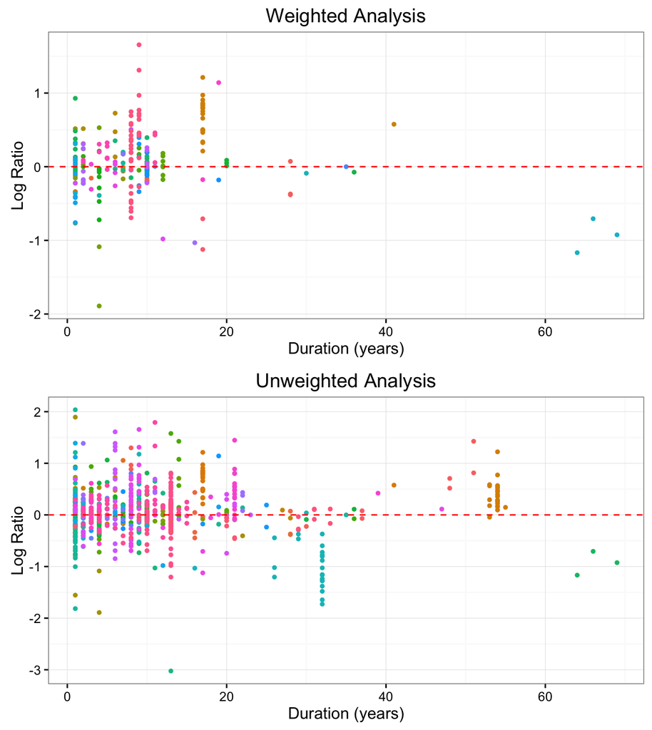

```r
duration_w <-
filter(fl_combined, !is.na(yi.SppR.ROM) & !is.na(vi.SppR.ROM) & vi.SppR.ROM > 0) %>%
ggplot(data = ., aes(x = Duration, y = yi.SppR.ROM, colour = as.factor(Study.ID))) +
  geom_point(size = 1) +
  ylab('Log Ratio') +
  theme_bw() +
  theme(legend.position = 'none') +
  geom_hline(yintercept = 0, colour = 'red', linetype = 'dashed') +
  ggtitle('Weighted Analysis') +
  xlab('Duration (years)') #+
  #ylim(-2, 2)

duration_uw <-
filter(fl_combined, !is.na(yi.SppR.ROM)) %>%
ggplot(data = ., aes(x = Duration, y = yi.SppR.ROM, colour = as.factor(Study.ID))) +
  geom_point(size = 1) +
  ylab('Log Ratio') +
  theme_bw() +
  theme(legend.position = 'none') +
  geom_hline(yintercept = 0, colour = 'red', linetype = 'dashed') +
  ggtitle('Unweighted Analysis') +
  xlab('Duration (years)') #+
  #ylim(-3, 3)

grid.arrange(duration_w, duration_uw, nrow = 2)
```

Both the weighted and unweighted naive models, where duration is the only predictor, show no significant change in species richness on average.

### Cumulative human impacts model

#### Comparison between the cumulative impact model with no event and full datasets for weighted and unweighted analyses

```r
impact_ne_w <-
  rma.mv(yi = yi.SppR.ROM, V = vi.SppR.ROM,
         data = no_event,
         random = ~ 1 | factor(Study.ID),
         mods = ~ Duration * mean_imps)
impact_ne_w
```

```
##
## Multivariate Meta-Analysis Model (k = 81; method: REML)
##
## Variance Components:
##
##             estim    sqrt  nlvls  fixed            factor
## sigma^2    0.0408  0.2021     22     no  factor(Study.ID)
##
## Test for Residual Heterogeneity:
## QE(df = 77) = 599.8969, p-val < .0001
##
## Test of Moderators (coefficient(s) 2,3,4):
## QM(df = 3) = 48.2948, p-val < .0001
##
## Model Results:
##
##                     estimate      se     zval    pval    ci.lb   ci.ub
## intrcpt              -0.1305  0.1114  -1.1716  0.2414  -0.3488  0.0878
## Duration             -0.0150  0.0117  -1.2822  0.1998  -0.0380  0.0079
## mean_imps             0.0305  0.0203   1.5060  0.1321  -0.0092  0.0703
## Duration:mean_imps    0.0059  0.0018   3.2216  0.0013   0.0023  0.0095  **
##
## ---
## Signif. codes:  0 '***' 0.001 '**' 0.01 '*' 0.05 '.' 0.1 ' ' 1
```

```r
impact_all_w <-
  rma.mv(yi = yi.SppR.ROM, V = vi.SppR.ROM,
         data = fl_combined,
         random = ~ 1 | factor(Study.ID),
         mods = ~ Duration * mean_imps)
impact_all_w
```

```
##
## Multivariate Meta-Analysis Model (k = 132; method: REML)
##
## Variance Components:
##
##             estim    sqrt  nlvls  fixed            factor
## sigma^2    0.1046  0.3235     36     no  factor(Study.ID)
##
## Test for Residual Heterogeneity:
## QE(df = 128) = 3481.2294, p-val < .0001
##
## Test of Moderators (coefficient(s) 2,3,4):
## QM(df = 3) = 12.5860, p-val = 0.0056
##
## Model Results:
##
##                     estimate      se     zval    pval    ci.lb    ci.ub
## intrcpt               0.0431  0.1003   0.4295  0.6676  -0.1535   0.2396
## Duration             -0.0208  0.0082  -2.5386  0.0111  -0.0368  -0.0047  *
## mean_imps             0.0040  0.0151   0.2670  0.7894  -0.0255   0.0336
## Duration:mean_imps    0.0028  0.0014   1.9556  0.0505  -0.0000   0.0056  .
##
## ---
## Signif. codes:  0 '***' 0.001 '**' 0.01 '*' 0.05 '.' 0.1 ' ' 1
```

```r
impact_lme_ne <-
  lme(yi.SppR.ROM ~ Duration * mean_imps, random = ~ 1 | factor(Study.ID),
      data = no_event, na.action = na.omit)
summary(impact_lme_ne)
```

```
## Linear mixed-effects model fit by REML
##  Data: no_event
##        AIC      BIC    logLik
##   389.8134 413.7922 -188.9067
##
## Random effects:
##  Formula: ~1 | factor(Study.ID)
##         (Intercept)  Residual
## StdDev:   0.3068339 0.3212518
##
## Fixed effects: yi.SppR.ROM ~ Duration * mean_imps
##                          Value  Std.Error  DF   t-value p-value
## (Intercept)        -0.17671467 0.10959623 309 -1.612416  0.1079
## Duration            0.00517413 0.00515468 309  1.003774  0.3163
## mean_imps           0.04144438 0.02308232 309  1.795503  0.0736
## Duration:mean_imps -0.00067998 0.00090500 309 -0.751365  0.4530
##  Correlation:
##                    (Intr) Duratn mn_mps
## Duration           -0.676
## mean_imps          -0.878  0.530
## Duration:mean_imps  0.647 -0.776 -0.722
##
## Standardized Within-Group Residuals:
##         Min          Q1         Med          Q3         Max
## -4.93602324 -0.50869995 -0.01442166  0.53001602  3.02483665
##
## Number of Observations: 406
## Number of Groups: 94
```

```r
impact_lme_all <-
  lme(yi.SppR.ROM ~ Duration * mean_imps, random = ~ 1 | factor(Study.ID),
      data = fl_combined, na.action = na.omit)

data_frame(parameter = rownames(impact_ne_w$b),
           ne_rma_per_change  = as.vector(get_percent_change(impact_ne_w$b)),
           ne_rma_pval  = impact_ne_w$pval,
           all_rma_per_change = as.vector(get_percent_change(impact_all_w$b)),
           all_rma_pval = impact_all_w$pval,
           #parameter_lme = rownames(summary(impact_lme_ne)$tTable),
           lme_ne_per_change  = as.vector(get_percent_change(summary(impact_lme_ne)$tTable[, 1])),
           lme_ne_pval  = summary(impact_lme_ne)$tTable[, 5],
           lme_all_per_change = as.vector(get_percent_change(summary(impact_lme_all)$tTable[, 1])),
           lme_all_pval = summary(impact_lme_all)$tTable[, 5]
           ) %>%
pandoc.table(.)
```

```
##
## -----------------------------------------------------------------------------------------------------------------------------------------------
##     parameter       ne_rma_per_change   ne_rma_pval   all_rma_per_change   all_rma_pval   lme_ne_per_change   lme_ne_pval   lme_all_per_change
## ------------------ ------------------- ------------- -------------------- -------------- ------------------- ------------- --------------------
##      intrcpt           -12.2339211      0.241358937       4.4006180         0.66759042      -16.19811371      0.10789236       -9.92405720
##
##      Duration          -1.4916923       0.199772526       -2.0571033        0.01112966       0.51875399       0.31627286        0.27110270
##
##     mean_imps           3.1002005       0.132065105       0.4032125         0.78944813       4.23151855       0.07355049        3.30290710
##
## Duration:mean_imps      0.5910139       0.001274583       0.2802567         0.05050660       -0.06797537      0.45300486       -0.07155321
## -----------------------------------------------------------------------------------------------------------------------------------------------
##
## Table: Table continues below
##
##
## --------------
##  lme_all_pval
## --------------
##   0.2679078
##
##   0.5915525
##
##   0.0743234
##
##   0.4176906
## --------------
```

### Specific driver model selection (study specific time slices)

Duration(I + VOCC - LTC - Nut)  
Duration(I + V + I*L + LTC - N +I*N + L*N + VOCC)  
(with both vocc and ltc, with just vocc, and with just ltc)  
- Use AIC for model selection

#### Weighted analyses using the no event data

```r
# Simplest model with all drivers
global_ne_all_drivers <-
    rma.mv(yi = yi.SppR.ROM, V = vi.SppR.ROM,
          data = no_event,
          random = ~ 1 | Study.ID,
          mods = ~ Duration * (mean_invs + mean_vocc + mean_lin_change + mean_nuts)
)
global_ne_all_drivers
```

```
##
## Multivariate Meta-Analysis Model (k = 72; method: REML)
##
## Variance Components:
##
##             estim    sqrt  nlvls  fixed    factor
## sigma^2    0.0623  0.2497     24     no  Study.ID
##
## Test for Residual Heterogeneity:
## QE(df = 62) = 681.3780, p-val < .0001
##
## Test of Moderators (coefficient(s) 2,3,4,5,6,7,8,9,10):
## QM(df = 9) = 29.7903, p-val = 0.0005
##
## Model Results:
##
##                           estimate      se     zval    pval    ci.lb    ci.ub
## intrcpt                    -0.0933  0.0830  -1.1245  0.2608  -0.2559   0.0693
## Duration                    0.0127  0.0075   1.7083  0.0876  -0.0019   0.0273   .
## mean_invs                   0.0000  0.0000   1.6333  0.1024  -0.0000   0.0000
## mean_vocc                   0.0003  0.0001   2.8370  0.0046   0.0001   0.0005  **
## mean_lin_change            -0.0374  0.0158  -2.3661  0.0180  -0.0683  -0.0064   *
## mean_nuts                  -0.0003  0.0006  -0.6276  0.5302  -0.0014   0.0007
## Duration:mean_invs         -0.0000  0.0000  -1.6539  0.0982  -0.0000   0.0000   .
## Duration:mean_vocc         -0.0000  0.0000  -0.4036  0.6865  -0.0000   0.0000
## Duration:mean_lin_change   -0.0000  0.0038  -0.0112  0.9910  -0.0075   0.0074
## Duration:mean_nuts          0.0005  0.0002   2.2648  0.0235   0.0001   0.0009   *
##
## ---
## Signif. codes:  0 '***' 0.001 '**' 0.01 '*' 0.05 '.' 0.1 ' ' 1
```

```r
global_ne_no_vocc <-
    rma.mv(yi = yi.SppR.ROM, V = vi.SppR.ROM,
          data = no_event,
          random = ~ 1 | Study.ID,
          mods = ~ Duration * (mean_invs + mean_lin_change + mean_nuts)
)
global_ne_no_vocc
```

```
##
## Multivariate Meta-Analysis Model (k = 72; method: REML)
##
## Variance Components:
##
##             estim    sqrt  nlvls  fixed    factor
## sigma^2    0.0542  0.2328     24     no  Study.ID
##
## Test for Residual Heterogeneity:
## QE(df = 64) = 729.1676, p-val < .0001
##
## Test of Moderators (coefficient(s) 2,3,4,5,6,7,8):
## QM(df = 7) = 21.6237, p-val = 0.0029
##
## Model Results:
##
##                           estimate      se     zval    pval    ci.lb   ci.ub
## intrcpt                    -0.0744  0.0751  -0.9909  0.3217  -0.2215  0.0727
## Duration                    0.0120  0.0062   1.9414  0.0522  -0.0001  0.0242  .
## mean_invs                  -0.0000  0.0000  -0.2526  0.8006  -0.0000  0.0000
## mean_lin_change            -0.0018  0.0052  -0.3396  0.7341  -0.0119  0.0084
## mean_nuts                  -0.0002  0.0005  -0.4373  0.6619  -0.0013  0.0008
## Duration:mean_invs          0.0000  0.0000   0.1983  0.8428  -0.0000  0.0000
## Duration:mean_lin_change   -0.0005  0.0009  -0.5858  0.5580  -0.0022  0.0012
## Duration:mean_nuts          0.0004  0.0002   2.1854  0.0289   0.0000  0.0008  *
##
## ---
## Signif. codes:  0 '***' 0.001 '**' 0.01 '*' 0.05 '.' 0.1 ' ' 1
```

```r
global_ne_no_ltc <-
    rma.mv(yi = yi.SppR.ROM, V = vi.SppR.ROM,
          data = no_event,
          random = ~ 1 | Study.ID,
          mods = ~ Duration * (mean_invs + mean_vocc + mean_nuts)
)
global_ne_no_ltc
```

```
##
## Multivariate Meta-Analysis Model (k = 72; method: REML)
##
## Variance Components:
##
##             estim    sqrt  nlvls  fixed    factor
## sigma^2    0.0542  0.2329     24     no  Study.ID
##
## Test for Residual Heterogeneity:
## QE(df = 64) = 731.4350, p-val < .0001
##
## Test of Moderators (coefficient(s) 2,3,4,5,6,7,8):
## QM(df = 7) = 21.2225, p-val = 0.0035
##
## Model Results:
##
##                     estimate      se     zval    pval    ci.lb   ci.ub
## intrcpt              -0.0771  0.0762  -1.0108  0.3121  -0.2265  0.0724
## Duration              0.0127  0.0065   1.9465  0.0516  -0.0001  0.0255  .
## mean_invs            -0.0000  0.0000  -0.0673  0.9464  -0.0000  0.0000
## mean_vocc             0.0000  0.0000   0.4742  0.6353  -0.0001  0.0001
## mean_nuts            -0.0002  0.0005  -0.3887  0.6975  -0.0013  0.0008
## Duration:mean_invs    0.0000  0.0000   0.0274  0.9782  -0.0000  0.0000
## Duration:mean_vocc   -0.0000  0.0000  -0.8412  0.4003  -0.0000  0.0000
## Duration:mean_nuts    0.0004  0.0002   2.1365  0.0326   0.0000  0.0008  *
##
## ---
## Signif. codes:  0 '***' 0.001 '**' 0.01 '*' 0.05 '.' 0.1 ' ' 1
```

```r
data_frame(parameter = rownames(global_ne_all_drivers$b),
           all_drivers_percent  = as.vector(get_percent_change(global_ne_all_drivers$b)),
           all_drivers_pval  = global_ne_all_drivers$pval
           ) %>%
  left_join(., data_frame(parameter = rownames(global_ne_no_vocc$b),
                         no_vocc_percent = as.vector(get_percent_change(global_ne_no_vocc$b)),
                         no_vocc_pval = global_ne_no_vocc$pval)) %>%
  left_join(., data_frame(parameter = rownames(global_ne_no_ltc$b),
                         no_ltc_percent = as.vector(get_percent_change(global_ne_no_ltc$b)),
                         no_ltc_pval = global_ne_no_ltc$pval)) %>%
pandoc.table(.)
```

```
##
## ---------------------------------------------------------------------------------------------------------------------------------
##        parameter          all_drivers_percent   all_drivers_pval   no_vocc_percent   no_vocc_pval   no_ltc_percent   no_ltc_pval
## ------------------------ --------------------- ------------------ ----------------- -------------- ---------------- -------------
##         intrcpt              -8.907979e+00        0.260790141       -7.167473e+00     0.32171618    -7.417300e+00    0.31212976
##
##         Duration             1.281757e+00         0.087583713       1.209786e+00      0.05220494     1.280710e+00    0.05159566
##
##        mean_invs             7.674772e-04         0.102401441       -8.994539e-05     0.80058691    -2.547571e-05    0.94636861
##
##        mean_vocc             3.159962e-02         0.004554533            NA               NA         1.805961e-03    0.63533218
##
##     mean_lin_change          -3.667071e+00        0.017974771       -1.756359e-01     0.73412630          NA             NA
##
##        mean_nuts             -3.488807e-02        0.530240065       -2.332618e-02     0.66190237    -2.081273e-02    0.69749868
##
##    Duration:mean_invs        -4.714837e-05        0.098151757       4.277146e-06      0.84283920     6.267923e-07    0.97817768
##
##    Duration:mean_vocc        -6.860642e-04        0.686542925            NA               NA        -3.310235e-04    0.40025571
##
## Duration:mean_lin_change     -4.285556e-03        0.991041131       -5.077808e-02     0.55798420          NA             NA
##
##    Duration:mean_nuts        4.702206e-02         0.023521947       4.332294e-02      0.02886179     4.251117e-02    0.03263925
## ---------------------------------------------------------------------------------------------------------------------------------
```

#### Weighted analyses using the full dataset

```r
# Simplest model with all drivers
global_full_all_drivers <-
    rma.mv(yi = yi.SppR.ROM, V = vi.SppR.ROM,
          data = fl_combined,
          random = ~ 1 | Study.ID,
          mods = ~ Duration * (mean_invs + mean_vocc + mean_lin_change + mean_nuts)
)
global_full_all_drivers
```

```
##
## Multivariate Meta-Analysis Model (k = 112; method: REML)
##
## Variance Components:
##
##             estim    sqrt  nlvls  fixed    factor
## sigma^2    0.1224  0.3499     36     no  Study.ID
##
## Test for Residual Heterogeneity:
## QE(df = 102) = 2494.0088, p-val < .0001
##
## Test of Moderators (coefficient(s) 2,3,4,5,6,7,8,9,10):
## QM(df = 9) = 26.2439, p-val = 0.0019
##
## Model Results:
##
##                           estimate      se     zval    pval    ci.lb   ci.ub
## intrcpt                    -0.0292  0.0810  -0.3607  0.7183  -0.1880  0.1296
## Duration                   -0.0032  0.0044  -0.7372  0.4610  -0.0117  0.0053
## mean_invs                   0.0000  0.0000   0.7925  0.4281  -0.0000  0.0000
## mean_vocc                   0.0002  0.0001   1.6180  0.1057  -0.0000  0.0003
## mean_lin_change            -0.0180  0.0144  -1.2492  0.2116  -0.0462  0.0102
## mean_nuts                  -0.0005  0.0005  -0.8794  0.3792  -0.0016  0.0006
## Duration:mean_invs         -0.0000  0.0000  -0.8913  0.3727  -0.0000  0.0000
## Duration:mean_vocc          0.0000  0.0000   0.4284  0.6684  -0.0000  0.0000
## Duration:mean_lin_change   -0.0021  0.0034  -0.6178  0.5367  -0.0088  0.0046
## Duration:mean_nuts          0.0005  0.0002   2.8264  0.0047   0.0002  0.0009  **
##
## ---
## Signif. codes:  0 '***' 0.001 '**' 0.01 '*' 0.05 '.' 0.1 ' ' 1
```

```r
global_full_no_vocc <-
    rma.mv(yi = yi.SppR.ROM, V = vi.SppR.ROM,
          data = fl_combined,
          random = ~ 1 | Study.ID,
          mods = ~ Duration * (mean_invs + mean_lin_change + mean_nuts)
)
global_full_no_vocc
```

```
##
## Multivariate Meta-Analysis Model (k = 112; method: REML)
##
## Variance Components:
##
##             estim    sqrt  nlvls  fixed    factor
## sigma^2    0.1231  0.3509     36     no  Study.ID
##
## Test for Residual Heterogeneity:
## QE(df = 104) = 2679.2612, p-val < .0001
##
## Test of Moderators (coefficient(s) 2,3,4,5,6,7,8):
## QM(df = 7) = 21.3061, p-val = 0.0033
##
## Model Results:
##
##                           estimate      se     zval    pval    ci.lb   ci.ub
## intrcpt                    -0.0208  0.0808  -0.2575  0.7968  -0.1791  0.1375
## Duration                   -0.0028  0.0043  -0.6559  0.5119  -0.0112  0.0056
## mean_invs                  -0.0000  0.0000  -0.4072  0.6839  -0.0000  0.0000
## mean_lin_change            -0.0036  0.0053  -0.6836  0.4942  -0.0139  0.0067
## mean_nuts                  -0.0003  0.0005  -0.6318  0.5275  -0.0014  0.0007
## Duration:mean_invs          0.0000  0.0000   0.3059  0.7597  -0.0000  0.0000
## Duration:mean_lin_change   -0.0002  0.0009  -0.1880  0.8509  -0.0020  0.0016
## Duration:mean_nuts          0.0005  0.0002   2.6007  0.0093   0.0001  0.0009  **
##
## ---
## Signif. codes:  0 '***' 0.001 '**' 0.01 '*' 0.05 '.' 0.1 ' ' 1
```

```r
global_full_no_ltc <-
    rma.mv(yi = yi.SppR.ROM, V = vi.SppR.ROM,
          data = fl_combined,
          random = ~ 1 | Study.ID,
          mods = ~ Duration * (mean_invs + mean_vocc + mean_nuts)
)
global_full_no_ltc
```

```
##
## Multivariate Meta-Analysis Model (k = 112; method: REML)
##
## Variance Components:
##
##             estim    sqrt  nlvls  fixed    factor
## sigma^2    0.1209  0.3477     36     no  Study.ID
##
## Test for Residual Heterogeneity:
## QE(df = 104) = 2602.7175, p-val < .0001
##
## Test of Moderators (coefficient(s) 2,3,4,5,6,7,8):
## QM(df = 7) = 20.2742, p-val = 0.0050
##
## Model Results:
##
##                     estimate      se     zval    pval    ci.lb   ci.ub
## intrcpt              -0.0168  0.0801  -0.2092  0.8343  -0.1738  0.1403
## Duration             -0.0030  0.0043  -0.7139  0.4753  -0.0114  0.0053
## mean_invs            -0.0000  0.0000  -0.2866  0.7744  -0.0000  0.0000
## mean_vocc            -0.0000  0.0000  -0.0102  0.9919  -0.0001  0.0001
## mean_nuts            -0.0003  0.0005  -0.6275  0.5303  -0.0014  0.0007
## Duration:mean_invs    0.0000  0.0000   0.1927  0.8472  -0.0000  0.0000
## Duration:mean_vocc   -0.0000  0.0000  -0.1209  0.9037  -0.0000  0.0000
## Duration:mean_nuts    0.0005  0.0002   2.6014  0.0093   0.0001  0.0009  **
##
## ---
## Signif. codes:  0 '***' 0.001 '**' 0.01 '*' 0.05 '.' 0.1 ' ' 1
```

```r
data_frame(parameter = rownames(global_full_all_drivers$b),
           all_drivers_percent  = as.vector(get_percent_change(global_full_all_drivers$b)),
           all_drivers_pval  = global_full_all_drivers$pval
           ) %>%
  left_join(., data_frame(parameter = rownames(global_full_no_vocc$b),
                         no_vocc_percent = as.vector(get_percent_change(global_full_no_vocc$b)),
                         no_vocc_pval = global_full_no_vocc$pval)) %>%
  left_join(., data_frame(parameter = rownames(global_full_no_ltc$b),
                         no_ltc_percent = as.vector(get_percent_change(global_full_no_ltc$b)),
                         no_ltc_pval = global_full_no_ltc$pval)) %>%
pandoc.table(.)
```

```
##
## ---------------------------------------------------------------------------------------------------------------------------------
##        parameter          all_drivers_percent   all_drivers_pval   no_vocc_percent   no_vocc_pval   no_ltc_percent   no_ltc_pval
## ------------------------ --------------------- ------------------ ----------------- -------------- ---------------- -------------
##         intrcpt              -2.879443e+00        0.718341229       -2.058081e+00    0.796828235    -1.661775e+00    0.834327674
##
##         Duration             -3.201651e-01        0.461008214       -2.793334e-01    0.511910067    -3.042812e-01    0.475272915
##
##        mean_invs             3.494648e-04         0.428061369       -1.519030e-04    0.683870911    -1.131565e-04    0.774397433
##
##        mean_vocc             1.516406e-02         0.105661609            NA               NA        -3.775175e-05    0.991860039
##
##     mean_lin_change          -1.783963e+00        0.211578047       -3.599407e-01    0.494221746          NA             NA
##
##        mean_nuts             -4.802104e-02        0.379190681       -3.406233e-02    0.527507091    -3.387263e-02    0.530326660
##
##    Duration:mean_invs        -2.379862e-05        0.372742306       6.918092e-06     0.759702829     4.606902e-06    0.847211581
##
##    Duration:mean_vocc        6.464974e-04         0.668396094            NA               NA        -4.993271e-05    0.903742288
##
## Duration:mean_lin_change     -2.096017e-01        0.536687478       -1.725807e-02    0.850870676          NA             NA
##
##    Duration:mean_nuts        5.469801e-02         0.004708133       4.937699e-02     0.009303057     4.951541e-02    0.009284622
## ---------------------------------------------------------------------------------------------------------------------------------
```

### Attempt with the full interaction models: Duration*(I + VOCC + I*L + LTC - N +I*N + L*N)

The full interaction models do not converge when we use the weighted meta-regression. They do converge for the full model

```r
global_ne_all_interactions <-
    rma.mv(yi = yi.SppR.ROM, V = vi.SppR.ROM,
          data = no_event,
          random = ~ 1 | Study.ID,
          mods = ~ Duration * (mean_invs + mean_vocc + mean_invs*mean_lin_change + mean_lin_change + mean_nuts + mean_invs*mean_nuts + mean_lin_change*mean_nuts)
)

global_all_interactions <-
    rma.mv(yi = yi.SppR.ROM, V = vi.SppR.ROM,
          data = fl_combined,
          random = ~ 1 | Study.ID,
          mods = ~ Duration * (mean_invs + mean_vocc + mean_invs*mean_lin_change + mean_lin_change + mean_nuts + mean_invs*mean_nuts + mean_lin_change*mean_nuts)
)
```

```r
global_all_invs_ltc_interaction <-
    rma.mv(yi = yi.SppR.ROM, V = vi.SppR.ROM,
          data = fl_combined,
          random = ~ 1 | Study.ID,
          mods = ~ Duration * (mean_invs + mean_invs*mean_lin_change + mean_lin_change + mean_nuts + mean_vocc)
)
global_all_invs_ltc_interaction
```

```
##
## Multivariate Meta-Analysis Model (k = 112; method: REML)
##
## Variance Components:
##
##             estim    sqrt  nlvls  fixed    factor
## sigma^2    0.1165  0.3414     36     no  Study.ID
##
## Test for Residual Heterogeneity:
## QE(df = 100) = 2480.3010, p-val < .0001
##
## Test of Moderators (coefficient(s) 2,3,4,5,6,7,8,9,10,11,12):
## QM(df = 11) = 31.3010, p-val = 0.0010
##
## Model Results:
##
##                                     estimate      se     zval    pval    ci.lb    ci.ub
## intrcpt                              -0.0473  0.0815  -0.5809  0.5613  -0.2070   0.1123
## Duration                             -0.0013  0.0044  -0.2937  0.7690  -0.0099   0.0073
## mean_invs                             0.0000  0.0000   2.1269  0.0334   0.0000   0.0001   *
## mean_lin_change                      -0.0202  0.0146  -1.3782  0.1681  -0.0489   0.0085
## mean_nuts                            -0.0009  0.0006  -1.4778  0.1395  -0.0020   0.0003
## mean_vocc                             0.0001  0.0001   1.3081  0.1908  -0.0001   0.0003
## mean_invs:mean_lin_change             0.0000  0.0000   0.1818  0.8557  -0.0000   0.0000
## Duration:mean_invs                   -0.0000  0.0000  -2.2092  0.0272  -0.0000  -0.0000   *
## Duration:mean_lin_change             -0.0001  0.0035  -0.0267  0.9787  -0.0070   0.0068
## Duration:mean_nuts                    0.0006  0.0002   2.8238  0.0047   0.0002   0.0009  **
## Duration:mean_vocc                   -0.0000  0.0000  -0.0958  0.9237  -0.0000   0.0000
## Duration:mean_invs:mean_lin_change    0.0000  0.0000   2.2249  0.0261   0.0000   0.0000   *
##
## ---
## Signif. codes:  0 '***' 0.001 '**' 0.01 '*' 0.05 '.' 0.1 ' ' 1
```

```r
global_ne_all_interactions_lme <-
  lme(yi.SppR.ROM ~ Duration * (mean_invs + mean_vocc + mean_invs*mean_lin_change + mean_lin_change + mean_nuts + mean_invs*mean_nuts + mean_lin_change*mean_nuts),
      random = ~ 1 | factor(Study.ID),
      data = no_event, na.action = na.omit)
summary(global_ne_all_interactions_lme)
```

```
## Linear mixed-effects model fit by REML
##  Data: no_event
##        AIC      BIC    logLik
##   550.0984 617.9843 -257.0492
##
## Random effects:
##  Formula: ~1 | factor(Study.ID)
##         (Intercept)  Residual
## StdDev:   0.1884867 0.3002551
##
## Fixed effects: yi.SppR.ROM ~ Duration * (mean_invs + mean_vocc + mean_invs *      mean_lin_change + mean_lin_change + mean_nuts + mean_invs *      mean_nuts + mean_lin_change * mean_nuts)
##                                           Value  Std.Error  DF    t-value p-value
## (Intercept)                        -0.008045043 0.04609488 233 -0.1745323  0.8616
## Duration                            0.003896397 0.00304547 233  1.2794066  0.2020
## mean_invs                           0.000003179 0.00000465 233  0.6833032  0.4951
## mean_vocc                          -0.000110907 0.00007525 233 -1.4738967  0.1419
## mean_lin_change                     0.019702966 0.02000063 233  0.9851175  0.3256
## mean_nuts                           0.001875150 0.00128701 233  1.4569820  0.1465
## mean_invs:mean_lin_change           0.000001863 0.00000367 233  0.5077367  0.6121
## mean_invs:mean_nuts                -0.000000095 0.00000008 233 -1.1949880  0.2333
## mean_lin_change:mean_nuts          -0.000616902 0.00106256 233 -0.5805810  0.5621
## Duration:mean_invs                 -0.000000258 0.00000034 233 -0.7706070  0.4417
## Duration:mean_vocc                  0.000017683 0.00001953 233  0.9054666  0.3662
## Duration:mean_lin_change           -0.003441876 0.00511434 233 -0.6729860  0.5016
## Duration:mean_nuts                 -0.000156969 0.00030660 233 -0.5119662  0.6092
## Duration:mean_invs:mean_lin_change -0.000000203 0.00000027 233 -0.7609043  0.4475
## Duration:mean_invs:mean_nuts        0.000000013 0.00000001 233  1.2003745  0.2312
## Duration:mean_lin_change:mean_nuts  0.000037813 0.00036282 233  0.1042186  0.9171
##  Correlation:
##                                    (Intr) Duratn mn_nvs mn_vcc mn_ln_ mn_nts mn_:__ mn_n:_ mn__:_ Drtn:mn_nv Drtn:mn_v Drt:__ Drtn:mn_nt D:_:__
## Duration                           -0.715
## mean_invs                          -0.339  0.301
## mean_vocc                           0.020  0.118 -0.175
## mean_lin_change                     0.036 -0.140  0.152 -0.827
## mean_nuts                          -0.246  0.326  0.703 -0.022  0.048
## mean_invs:mean_lin_change          -0.291  0.208  0.744 -0.295  0.190  0.406
## mean_invs:mean_nuts                 0.212 -0.227 -0.770  0.048 -0.115 -0.831 -0.341
## mean_lin_change:mean_nuts           0.231 -0.279 -0.728  0.010  0.001 -0.704 -0.550  0.723
## Duration:mean_invs                  0.289 -0.271 -0.925  0.124 -0.145 -0.745 -0.568  0.898  0.752
## Duration:mean_vocc                  0.112 -0.282  0.032 -0.646  0.706 -0.029  0.010 -0.084  0.072 -0.078
```

[output cut: 13 more lines]

```
## mean_lin_change:mean_nuts
## Duration:mean_invs
## Duration:mean_vocc
## Duration:mean_lin_change
## Duration:mean_nuts
## Duration:mean_invs:mean_lin_change
## Duration:mean_invs:mean_nuts
## Duration:mean_lin_change:mean_nuts  0.428
##
## Standardized Within-Group Residuals:
##          Min           Q1          Med           Q3          Max
## -3.116603842 -0.474924333  0.006747298  0.458425771  3.362651409
##
## Number of Observations: 337
## Number of Groups: 89
```

```r
global_all_interactions_lme <-
  lme(yi.SppR.ROM ~ Duration * (mean_invs + mean_vocc + mean_invs*mean_lin_change + mean_lin_change + mean_nuts + mean_invs*mean_nuts + mean_lin_change*mean_nuts),
      random = ~ 1 | factor(Study.ID),
      data = fl_combined, na.action = na.omit)
summary(global_all_interactions_lme)
```

```
## Linear mixed-effects model fit by REML
##  Data: fl_combined
##        AIC      BIC    logLik
##   841.6712 915.7572 -402.8356
##
## Random effects:
##  Formula: ~1 | factor(Study.ID)
##         (Intercept)  Residual
## StdDev:   0.2616096 0.3714955
##
## Fixed effects: yi.SppR.ROM ~ Duration * (mean_invs + mean_vocc + mean_invs *      mean_lin_change + mean_lin_change + mean_nuts + mean_invs *      mean_nuts + mean_lin_change * mean_nuts)
##                                          Value  Std.Error  DF    t-value p-value
## (Intercept)                         0.08188209 0.04909902 340  1.6676931  0.0963
## Duration                           -0.00246381 0.00302832 340 -0.8135886  0.4165
## mean_invs                          -0.00000119 0.00000465 340 -0.2556082  0.7984
## mean_vocc                          -0.00013003 0.00008359 340 -1.5554692  0.1208
## mean_lin_change                     0.01666756 0.02178815 340  0.7649828  0.4448
## mean_nuts                           0.00054435 0.00108026 340  0.5039058  0.6147
## mean_invs:mean_lin_change           0.00000152 0.00000410 340  0.3709374  0.7109
## mean_invs:mean_nuts                 0.00000001 0.00000007 340  0.1023544  0.9185
## mean_lin_change:mean_nuts          -0.00002828 0.00116084 340 -0.0243603  0.9806
## Duration:mean_invs                  0.00000003 0.00000034 340  0.0835354  0.9335
## Duration:mean_vocc                  0.00001125 0.00002094 340  0.5372014  0.5915
## Duration:mean_lin_change           -0.00100354 0.00555279 340 -0.1807271  0.8567
## Duration:mean_nuts                  0.00002043 0.00015974 340  0.1278761  0.8983
## Duration:mean_invs:mean_lin_change -0.00000005 0.00000029 340 -0.1656695  0.8685
## Duration:mean_invs:mean_nuts        0.00000000 0.00000001 340 -0.0512433  0.9592
## Duration:mean_lin_change:mean_nuts -0.00002776 0.00041849 340 -0.0663449  0.9471
##  Correlation:
##                                    (Intr) Duratn mn_nvs mn_vcc mn_ln_ mn_nts mn_:__ mn_n:_ mn__:_ Drtn:mn_nv Drtn:mn_v Drt:__ Drtn:mn_nt D:_:__
## Duration                           -0.683
## mean_invs                          -0.300  0.243
## mean_vocc                          -0.058  0.134 -0.157
## mean_lin_change                     0.061 -0.126  0.122 -0.830
## mean_nuts                          -0.274  0.282  0.684 -0.079  0.078
## mean_invs:mean_lin_change          -0.236  0.152  0.804 -0.245  0.162  0.542
## mean_invs:mean_nuts                 0.192 -0.189 -0.694  0.061 -0.098 -0.776 -0.390
## mean_lin_change:mean_nuts           0.204 -0.233 -0.657  0.010  0.015 -0.632 -0.571  0.647
## Duration:mean_invs                  0.254 -0.233 -0.910  0.114 -0.114 -0.740 -0.627  0.875  0.689
## Duration:mean_vocc                  0.090 -0.209  0.020 -0.662  0.681  0.015  0.029 -0.073  0.071 -0.055
```

[output cut: 13 more lines]

```
## mean_lin_change:mean_nuts
## Duration:mean_invs
## Duration:mean_vocc
## Duration:mean_lin_change
## Duration:mean_nuts
## Duration:mean_invs:mean_lin_change
## Duration:mean_invs:mean_nuts
## Duration:mean_lin_change:mean_nuts  0.305
##
## Standardized Within-Group Residuals:
##          Min           Q1          Med           Q3          Max
## -4.452361876 -0.425900509  0.002568023  0.381391235  4.830438460
##
## Number of Observations: 469
## Number of Groups: 114
```

```r
global_all_invs_ltc_interaction_lme <-
  lme(yi.SppR.ROM ~ Duration * (mean_invs + mean_vocc + mean_invs*mean_lin_change + mean_lin_change + mean_nuts),
      random = ~ 1 | factor(Study.ID),
      data = fl_combined, na.action = na.omit)
summary(global_all_invs_ltc_interaction_lme)
```

```
## Linear mixed-effects model fit by REML
##  Data: fl_combined
##        AIC      BIC    logLik
##   737.4465 795.1921 -354.7232
##
## Random effects:
##  Formula: ~1 | factor(Study.ID)
##         (Intercept)  Residual
## StdDev:   0.2572552 0.3712105
##
## Fixed effects: yi.SppR.ROM ~ Duration * (mean_invs + mean_vocc + mean_invs *      mean_lin_change + mean_lin_change + mean_nuts)
##                                          Value  Std.Error  DF    t-value p-value
## (Intercept)                         0.07755454 0.04666140 344  1.6620706  0.0974
## Duration                           -0.00223983 0.00290557 344 -0.7708756  0.4413
## mean_invs                           0.00000004 0.00000165 344  0.0224302  0.9821
## mean_vocc                          -0.00012963 0.00008008 344 -1.6186877  0.1064
## mean_lin_change                     0.01472046 0.02098936 344  0.7013297  0.4836
## mean_nuts                           0.00075281 0.00060534 344  1.2436050  0.2145
## mean_invs:mean_lin_change           0.00000101 0.00000069 344  1.4649477  0.1438
## Duration:mean_invs                  0.00000000 0.00000013 344 -0.0371430  0.9704
## Duration:mean_vocc                  0.00000971 0.00002043 344  0.4752102  0.6349
## Duration:mean_lin_change           -0.00057706 0.00545250 344 -0.1058349  0.9158
## Duration:mean_nuts                  0.00000705 0.00013791 344  0.0511564  0.9592
## Duration:mean_invs:mean_lin_change -0.00000004 0.00000010 344 -0.3492192  0.7271
##  Correlation:
##                                    (Intr) Duratn mn_nvs mn_vcc mn_ln_ mn_nts mn_:__ Drtn:mn_nv Drtn:mn_v Drt:__ Drtn:mn_nt
## Duration                           -0.669
## mean_invs                          -0.116  0.126
## mean_vocc                          -0.115  0.158  0.030
## mean_lin_change                     0.099 -0.137 -0.005 -0.827
## mean_nuts                          -0.124  0.178 -0.138  0.020 -0.014
## mean_invs:mean_lin_change          -0.001  0.011  0.236 -0.178  0.034  0.221
## Duration:mean_invs                  0.079 -0.095 -0.917  0.015 -0.006  0.076 -0.482
## Duration:mean_vocc                  0.096 -0.207 -0.003 -0.675  0.675 -0.029  0.076 -0.013
## Duration:mean_lin_change           -0.084  0.167 -0.004  0.637 -0.711  0.024 -0.053  0.014     -0.967
## Duration:mean_nuts                  0.080 -0.286  0.007 -0.053  0.051 -0.560  0.013 -0.110      0.090    -0.077
## Duration:mean_invs:mean_lin_change  0.043 -0.043 -0.785  0.084 -0.038  0.008 -0.675  0.960     -0.070     0.059 -0.143
##
## Standardized Within-Group Residuals:
##          Min           Q1          Med           Q3          Max
## -4.456312264 -0.437620009 -0.006896188  0.390554003  4.833616489
##
## Number of Observations: 469
## Number of Groups: 114
```

Key for the table:

- rma_interact_change = variance weighted analysis with the full dataset, with the following model: LR ~ Duration * (I + V + I*LTC + LTC + N)
- all_full_interact_change = unweighted analysis with the full dataset, with the following model: LR ~ Duration * (I + V + I*LTC + LTC + N + I*N + LTC*N)
- all_invs_ltc_int_change = unweighted analysis with the full dataset, with the following model: LR ~ Duration * (I + V + I*LTC + LTC + N)

```r
data_frame(parameter = rownames(global_all_invs_ltc_interaction$b),
           rma_interact_change  = as.vector(get_percent_change(global_all_invs_ltc_interaction$b)),
           rma_interact_pval  = global_all_invs_ltc_interaction$pval
           ) %>%
  left_join(., data_frame(parameter = rownames(summary(global_all_interactions_lme)$tTable),
                         all_full_interact_change = as.vector(get_percent_change(summary(global_all_interactions_lme)$tTable[, 1])),
                         all_full_interact_pval = as.vector(summary(global_all_interactions_lme)$tTable[, 5]))) %>%
  left_join(., data_frame(parameter = rownames(summary(global_all_invs_ltc_interaction_lme)$tTable),
                         all_invs_ltc_int_change = as.vector(get_percent_change(summary(global_all_invs_ltc_interaction_lme)$tTable[, 1])),
                         all_invs_ltc_int_pval = as.vector(summary(global_all_invs_ltc_interaction_lme)$tTable[, 5]))) %>%
pandoc.table(.)
```

```
##
## --------------------------------------------------------------------------------------------------------------------------------
##             parameter               rma_interact_change   rma_interact_pval   all_full_interact_change   all_full_interact_pval
## ---------------------------------- --------------------- ------------------- -------------------------- ------------------------
##              intrcpt                   -4.621968e+00         0.561299306                 NA                        NA
##
##              Duration                  -1.283651e-01         0.769016793           -2.460777e-01               0.4164501
##
##             mean_invs                  4.521368e-03          0.033427724           -1.187329e-04               0.7984079
##
##          mean_lin_change               -1.997641e+00         0.168141683            1.680724e+00               0.4448124
##
##             mean_nuts                  -8.541865e-02         0.139461234            5.444989e-02               0.6146539
##
##             mean_vocc                  1.281331e-02          0.190848661           -1.300192e-02               0.1207647
##
##     mean_invs:mean_lin_change          2.019322e-05          0.855720903            1.522637e-04               0.7109152
##
##         Duration:mean_invs             -3.476431e-04         0.027162493            2.874386e-06               0.9334750
##
##      Duration:mean_lin_change          -9.379472e-03         0.978704068           -1.003037e-01               0.8566894
##
##         Duration:mean_nuts             5.509440e-02          0.004746229            2.042681e-03               0.8983226
##
##         Duration:mean_vocc             -1.488922e-04         0.923675056            1.124755e-03               0.5914799
##
## Duration:mean_invs:mean_lin_change     1.697467e-04          0.026086275           -4.803291e-06               0.8685155
## --------------------------------------------------------------------------------------------------------------------------------
##
## Table: Table continues below
##
##
## -------------------------------------------------
##  all_invs_ltc_int_change   all_invs_ltc_int_pval
## ------------------------- -----------------------
##            NA                       NA
##
##       -2.237327e-01              0.4413098
##
##       3.693723e-06               0.9821178
##
##       1.482934e+00               0.4835714
##
##       7.530896e-02               0.2144918
##
##       -1.296180e-02              0.1064309
##
##       1.007487e-04               0.1438485
##
##       -4.950667e-07              0.9703925
##
##       -5.768980e-02              0.9157750
##
##       7.054887e-04               0.9592306
##
##       9.707802e-04               0.6349387
##
##       -3.651949e-06              0.7271385
## -------------------------------------------------
```

### Including initial species richness

In our predictions we have assumed that climate velocity is likely to lead to an influx of species into initially, relatively depauperate regions. We can include this assumption by including an interaction between initial species richness and mean climate velocity. We do not include this interaction with the other drivers because it is less clear how initial species richness will alter the effects of linear changes in temperature (too high too fast should result in loss regardless of the initial number of species), it is equivocal in the literature how invasive species relates to species richness (conflicting evidence), and nutrients (need to check, but I think just general declines in the long term? - e.g., paradox of enrichment?).

Jillian’’s reasoning for initial species richness interactions:

1. SppR1 * Invs - I do not think this should be included. In the literature, the relationship between initial diversity and invasives is equivocal. I think that this relationship is likely too context dependent to meaningfully include it in the model.
2. SppR1 * VOCC - loss is likely to be higher in low diversity (likely polar) locations where species are closer to thermal tolerances and this also accounts for the idea of poleward range expansions from species rich to depauperate areas.
3. SppR1 * LTC - same as VOCC. - probably need a better explanation/support
4. SppR1 * Nuts - may expect a non-linear relationship because more diverse systems may have a higher capacity to buffer nutrients (at least in the short term). (e.g., “Biodiversity improves water quality through niche partitioning” - Cardinale 2011 )

How much do we need to be concerned that the log ratio calculation includes SppR1? Does this matter if we are taking a predictive approach? Because if SppR1 is valuable as a predictor then the mechanism for why shouldn’’t matter.

```r
initial_richness_ne <-
    rma.mv(yi = yi.SppR.ROM, V = vi.SppR.ROM,
          data = no_event,
          random = ~ 1 | Study.ID,
          mods = ~ Duration * (mean_vocc + mean_lin_change + mean_nuts) * SppR1 + mean_invs*Duration
)
initial_richness_ne
```

```
##
## Multivariate Meta-Analysis Model (k = 72; method: REML)
##
## Variance Components:
##
##             estim    sqrt  nlvls  fixed    factor
## sigma^2    0.1868  0.4322     24     no  Study.ID
##
## Test for Residual Heterogeneity:
## QE(df = 54) = 461.1358, p-val < .0001
##
## Test of Moderators (coefficient(s) 2,3,4,5,6,7,8,9,10,11,12,13,14,15,16,17,18):
## QM(df = 17) = 119.2743, p-val < .0001
##
## Model Results:
##
##                                 estimate      se     zval    pval    ci.lb    ci.ub
## intrcpt                          -0.1184  0.2011  -0.5885  0.5562  -0.5126   0.2759
## Duration                          0.0248  0.0181   1.3689  0.1710  -0.0107   0.0603
## mean_vocc                         0.0006  0.0002   2.8044  0.0050   0.0002   0.0010   **
## mean_lin_change                  -0.0827  0.0372  -2.2206  0.0264  -0.1557  -0.0097    *
## mean_nuts                        -0.0170  0.0088  -1.9276  0.0539  -0.0342   0.0003    .
## SppR1                             0.0056  0.0086   0.6499  0.5158  -0.0112   0.0224
## mean_invs                         0.0000  0.0000   2.2240  0.0262   0.0000   0.0000    *
## Duration:mean_vocc                0.0000  0.0001   0.0497  0.9604  -0.0002   0.0002
## Duration:mean_lin_change          0.0061  0.0260   0.2362  0.8133  -0.0448   0.0571
## Duration:mean_nuts                0.0041  0.0011   3.8225  0.0001   0.0020   0.0062  ***
## Duration:SppR1                   -0.0010  0.0010  -1.0168  0.3093  -0.0029   0.0009
## mean_vocc:SppR1                  -0.0000  0.0000  -0.2887  0.7728  -0.0000   0.0000
## mean_lin_change:SppR1             0.0017  0.0037   0.4597  0.6457  -0.0055   0.0089
## mean_nuts:SppR1                   0.0012  0.0005   2.4628  0.0138   0.0002   0.0022    *
## Duration:mean_invs               -0.0000  0.0000  -2.1228  0.0338  -0.0000  -0.0000    *
## Duration:mean_vocc:SppR1         -0.0000  0.0000  -1.3658  0.1720  -0.0000   0.0000
## Duration:mean_lin_change:SppR1    0.0002  0.0014   0.1816  0.8559  -0.0024   0.0029
## Duration:mean_nuts:SppR1         -0.0004  0.0001  -4.8724  <.0001  -0.0005  -0.0002  ***
##
## ---
## Signif. codes:  0 '***' 0.001 '**' 0.01 '*' 0.05 '.' 0.1 ' ' 1
```

```r
initial_richness_all <-
    rma.mv(yi = yi.SppR.ROM, V = vi.SppR.ROM,
          data = fl_combined,
          random = ~ 1 | Study.ID,
          mods = ~ Duration * (mean_vocc + mean_lin_change + mean_nuts) * SppR1 + mean_invs*Duration
)
initial_richness_all
```

```
##
## Multivariate Meta-Analysis Model (k = 112; method: REML)
##
## Variance Components:
##
##             estim    sqrt  nlvls  fixed    factor
## sigma^2    0.1647  0.4059     36     no  Study.ID
##
## Test for Residual Heterogeneity:
## QE(df = 94) = 1672.6778, p-val < .0001
##
## Test of Moderators (coefficient(s) 2,3,4,5,6,7,8,9,10,11,12,13,14,15,16,17,18):
## QM(df = 17) = 77.9760, p-val < .0001
##
## Model Results:
##
##                                 estimate      se     zval    pval    ci.lb    ci.ub
## intrcpt                          -0.0213  0.1138  -0.1872  0.8515  -0.2444   0.2018
## Duration                          0.0067  0.0076   0.8766  0.3807  -0.0083   0.0216
## mean_vocc                         0.0004  0.0002   2.8967  0.0038   0.0001   0.0007   **
## mean_lin_change                  -0.0820  0.0245  -3.3470  0.0008  -0.1300  -0.0340  ***
## mean_nuts                        -0.0002  0.0062  -0.0356  0.9716  -0.0124   0.0119
## SppR1                             0.0020  0.0033   0.6077  0.5434  -0.0045   0.0085
## mean_invs                         0.0000  0.0000   0.9173  0.3590  -0.0000   0.0000
## Duration:mean_vocc               -0.0000  0.0000  -1.2617  0.2070  -0.0001   0.0000
## Duration:mean_lin_change          0.0211  0.0114   1.8567  0.0634  -0.0012   0.0434    .
## Duration:mean_nuts                0.0003  0.0006   0.4271  0.6693  -0.0009   0.0015
## Duration:SppR1                   -0.0007  0.0003  -2.6206  0.0088  -0.0013  -0.0002   **
## mean_vocc:SppR1                  -0.0000  0.0000  -2.0967  0.0360  -0.0000  -0.0000    *
## mean_lin_change:SppR1             0.0062  0.0021   2.9397  0.0033   0.0021   0.0103   **
## mean_nuts:SppR1                  -0.0000  0.0003  -0.0017  0.9986  -0.0007   0.0007
## Duration:mean_invs               -0.0000  0.0000  -0.8957  0.3704  -0.0000   0.0000
## Duration:mean_vocc:SppR1          0.0000  0.0000   1.1563  0.2476  -0.0000   0.0000
## Duration:mean_lin_change:SppR1   -0.0016  0.0007  -2.3552  0.0185  -0.0029  -0.0003    *
## Duration:mean_nuts:SppR1          0.0000  0.0000   0.2240  0.8227  -0.0001   0.0001
##
## ---
## Signif. codes:  0 '***' 0.001 '**' 0.01 '*' 0.05 '.' 0.1 ' ' 1
```

```r
# Unweighted analysis
initial_richness_ne_lme <-
  lme(yi.SppR.ROM ~ Duration * (mean_vocc + mean_lin_change + mean_nuts) * SppR1 + mean_invs*Duration,
      random = ~ 1 | factor(Study.ID),
      data = no_event, na.action = na.omit)
summary(initial_richness_ne_lme)
```

```
## Linear mixed-effects model fit by REML
##  Data: no_event
##        AIC      BIC    logLik
##   522.4094 597.7132 -241.2047
##
## Random effects:
##  Formula: ~1 | factor(Study.ID)
##         (Intercept)  Residual
## StdDev:   0.1849488 0.2937458
##
## Fixed effects: yi.SppR.ROM ~ Duration * (mean_vocc + mean_lin_change + mean_nuts) *      SppR1 + mean_invs * Duration
##                                      Value  Std.Error  DF    t-value p-value
## (Intercept)                     0.08345378 0.06365023 231  1.3111309  0.1911
## Duration                        0.00483125 0.00409609 231  1.1794789  0.2394
## mean_vocc                      -0.00004729 0.00009101 231 -0.5195769  0.6039
## mean_lin_change                -0.00836712 0.02726667 231 -0.3068624  0.7592
## mean_nuts                      -0.00417107 0.00324906 231 -1.2837775  0.2005
## SppR1                          -0.00500248 0.00235370 231 -2.1253741  0.0346
## mean_invs                       0.00000094 0.00000082 231  1.1461102  0.2529
## Duration:mean_vocc              0.00002141 0.00003306 231  0.6475563  0.5179
## Duration:mean_lin_change       -0.00401439 0.00970154 231 -0.4137887  0.6794
## Duration:mean_nuts              0.00089197 0.00045150 231  1.9755888  0.0494
## Duration:SppR1                  0.00002849 0.00010780 231  0.2643001  0.7918
## mean_vocc:SppR1                -0.00000505 0.00000513 231 -0.9840145  0.3261
## mean_lin_change:SppR1           0.00198920 0.00195148 231  1.0193278  0.3091
## mean_nuts:SppR1                 0.00025000 0.00017449 231  1.4326908  0.1533
## Duration:mean_invs             -0.00000002 0.00000002 231 -0.8730462  0.3835
## Duration:mean_vocc:SppR1       -0.00000007 0.00000153 231 -0.0435411  0.9653
## Duration:mean_lin_change:SppR1 -0.00007013 0.00054715 231 -0.1281754  0.8981
## Duration:mean_nuts:SppR1       -0.00004434 0.00002122 231 -2.0892294  0.0378
##  Correlation:
##                                (Intr) Duratn mn_vcc mn_ln_ mn_nts SppR1  mn_nvs Drtn:mn_v Drt:__ Drtn:mn_nt Dr:SR1 mn_v:SR1 m__:SR mn_n:SR1
## Duration                       -0.710
## mean_vocc                      -0.041 -0.009
## mean_lin_change                 0.005  0.074 -0.792
## mean_nuts                      -0.255  0.208 -0.112  0.055
## SppR1                          -0.727  0.426  0.102 -0.045  0.310
## mean_invs                       0.000  0.125  0.134 -0.082 -0.145 -0.067
## Duration:mean_vocc              0.034  0.019 -0.587  0.496 -0.059 -0.093 -0.212
## Duration:mean_lin_change       -0.010 -0.102  0.563 -0.540  0.078  0.083  0.157 -0.972
```

[output cut: 19 more lines]

```
## Duration:SppR1
## mean_vocc:SppR1
## mean_lin_change:SppR1
## mean_nuts:SppR1
## Duration:mean_invs
## Duration:mean_vocc:SppR1       -0.242
## Duration:mean_lin_change:SppR1  0.142     -0.939
## Duration:mean_nuts:SppR1       -0.125      0.109        -0.073
##
## Standardized Within-Group Residuals:
##         Min          Q1         Med          Q3         Max
## -3.28959731 -0.49096129  0.03506943  0.48547865  3.39337112
##
## Number of Observations: 337
## Number of Groups: 89
```

```r
initial_richness_all_lme <-
  lme(yi.SppR.ROM ~ Duration * (mean_vocc + mean_lin_change + mean_nuts) * SppR1 + mean_invs*Duration,
      random = ~ 1 | factor(Study.ID),
      data = fl_combined, na.action = na.omit)
summary(initial_richness_all_lme)
```

```
## Linear mixed-effects model fit by REML
##  Data: fl_combined
##        AIC      BIC    logLik
##   797.5753 879.8046 -378.7876
##
## Random effects:
##  Formula: ~1 | factor(Study.ID)
##         (Intercept)  Residual
## StdDev:   0.2984587 0.3500291
##
## Fixed effects: yi.SppR.ROM ~ Duration * (mean_vocc + mean_lin_change + mean_nuts) *      SppR1 + mean_invs * Duration
##                                      Value  Std.Error  DF   t-value p-value
## (Intercept)                     0.26859029 0.07191290 338  3.734939  0.0002
## Duration                       -0.00237581 0.00466904 338 -0.508844  0.6112
## mean_vocc                      -0.00021581 0.00010130 338 -2.130378  0.0339
## mean_lin_change                 0.02881139 0.03151146 338  0.914315  0.3612
## mean_nuts                      -0.00177377 0.00348288 338 -0.509283  0.6109
## SppR1                          -0.01160044 0.00258272 338 -4.491550  0.0000
## mean_invs                       0.00000035 0.00000092 338  0.379481  0.7046
## Duration:mean_vocc              0.00003573 0.00003642 338  0.981036  0.3273
## Duration:mean_lin_change       -0.00958630 0.01072070 338 -0.894185  0.3719
## Duration:mean_nuts              0.00058672 0.00044907 338  1.306529  0.1923
## Duration:SppR1                  0.00015643 0.00012415 338  1.259978  0.2085
## mean_vocc:SppR1                 0.00000749 0.00000581 338  1.289756  0.1980
## mean_lin_change:SppR1          -0.00163514 0.00216014 338 -0.756962  0.4496
## mean_nuts:SppR1                 0.00008712 0.00017776 338  0.490081  0.6244
## Duration:mean_invs              0.00000000 0.00000003 338 -0.165476  0.8687
## Duration:mean_vocc:SppR1       -0.00000194 0.00000167 338 -1.160115  0.2468
## Duration:mean_lin_change:SppR1  0.00065942 0.00058922 338  1.119129  0.2639
## Duration:mean_nuts:SppR1       -0.00001596 0.00001293 338 -1.234173  0.2180
##  Correlation:
##                                (Intr) Duratn mn_vcc mn_ln_ mn_nts SppR1  mn_nvs Drtn:mn_v Drt:__ Drtn:mn_nt Dr:SR1 mn_v:SR1 m__:SR mn_n:SR1
## Duration                       -0.684
## mean_vocc                      -0.065 -0.006
## mean_lin_change                -0.030  0.118 -0.795
## mean_nuts                      -0.249  0.170 -0.067  0.049
## SppR1                          -0.701  0.417  0.102 -0.027  0.355
## mean_invs                       0.000  0.154  0.089 -0.050 -0.053 -0.122
## Duration:mean_vocc             -0.009  0.071 -0.582  0.476 -0.066 -0.080 -0.171
## Duration:mean_lin_change        0.042 -0.170  0.558 -0.526  0.081  0.071  0.122 -0.968
```

[output cut: 19 more lines]

```
## Duration:SppR1
## mean_vocc:SppR1
## mean_lin_change:SppR1
## mean_nuts:SppR1
## Duration:mean_invs
## Duration:mean_vocc:SppR1       -0.164
## Duration:mean_lin_change:SppR1  0.084     -0.942
## Duration:mean_nuts:SppR1       -0.217     -0.006        -0.022
##
## Standardized Within-Group Residuals:
##         Min          Q1         Med          Q3         Max
## -4.39468113 -0.46312508  0.01579967  0.42518689  4.01765237
##
## Number of Observations: 469
## Number of Groups: 114
```

#### Issues with including initial richness as a predictor

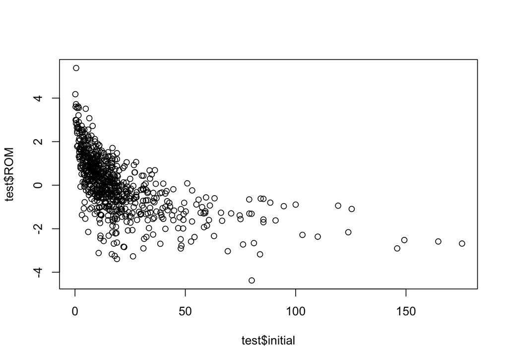

```r
x1 <- sample(na.omit(fl_combined$SppR1), size = 708, replace = FALSE)

x2 <- sample(na.omit(fl_combined$SppR2), size = 708, replace = FALSE)

test <- data.frame(ROM = log(x2 / x1), initial = x1)

plot(test$ROM ~ test$initial)
```

### Analysis without interactions between drivers

```r
global_ne <-
    rma.mv(yi = yi.SppR.ROM, V = vi.SppR.ROM,
          data = no_event,
          random = ~ 1 | Study.ID,
          mods = ~ Duration * (SppR1*mean_vocc + mean_lin_change + mean_invs +  mean_nuts)
)
global_ne
```

```
##
## Multivariate Meta-Analysis Model (k = 72; method: REML)
##
## Variance Components:
##
##             estim    sqrt  nlvls  fixed    factor
## sigma^2    0.2026  0.4501     24     no  Study.ID
##
## Test for Residual Heterogeneity:
## QE(df = 58) = 643.8356, p-val < .0001
##
## Test of Moderators (coefficient(s) 2,3,4,5,6,7,8,9,10,11,12,13,14):
## QM(df = 13) = 69.1375, p-val < .0001
##
## Model Results:
##
##                           estimate      se     zval    pval    ci.lb    ci.ub
## intrcpt                    -0.2847  0.1922  -1.4814  0.1385  -0.6615   0.0920
## Duration                    0.0589  0.0170   3.4578  0.0005   0.0255   0.0923  ***
## SppR1                       0.0186  0.0078   2.3981  0.0165   0.0034   0.0338    *
## mean_vocc                   0.0004  0.0001   2.7384  0.0062   0.0001   0.0007   **
## mean_lin_change            -0.0586  0.0179  -3.2717  0.0011  -0.0937  -0.0235   **
## mean_invs                   0.0000  0.0000   2.2477  0.0246   0.0000   0.0000    *
## mean_nuts                   0.0007  0.0006   1.0870  0.2770  -0.0006   0.0020
## SppR1:mean_vocc             0.0000  0.0000   2.3211  0.0203   0.0000   0.0000    *
## Duration:SppR1             -0.0035  0.0008  -4.1397  <.0001  -0.0051  -0.0018  ***
## Duration:mean_vocc         -0.0000  0.0000  -0.5909  0.5546  -0.0001   0.0000
## Duration:mean_lin_change    0.0080  0.0062   1.2783  0.2012  -0.0042   0.0202
## Duration:mean_invs         -0.0000  0.0000  -2.0358  0.0418  -0.0000  -0.0000    *
## Duration:mean_nuts         -0.0001  0.0003  -0.3531  0.7240  -0.0006   0.0004
## Duration:SppR1:mean_vocc   -0.0000  0.0000  -3.6060  0.0003  -0.0000  -0.0000  ***
##
## ---
## Signif. codes:  0 '***' 0.001 '**' 0.01 '*' 0.05 '.' 0.1 ' ' 1
```

```r
global_all <-
    rma.mv(yi = yi.SppR.ROM, V = vi.SppR.ROM,
          data = fl_combined,
          random = ~ 1 | Study.ID,
          mods = ~ Duration * (mean_vocc + mean_invs +  mean_nuts)
)
global_all
```

```
##
## Multivariate Meta-Analysis Model (k = 112; method: REML)
##
## Variance Components:
##
##             estim    sqrt  nlvls  fixed    factor
## sigma^2    0.1209  0.3477     36     no  Study.ID
##
## Test for Residual Heterogeneity:
## QE(df = 104) = 2602.7175, p-val < .0001
##
## Test of Moderators (coefficient(s) 2,3,4,5,6,7,8):
## QM(df = 7) = 20.2742, p-val = 0.0050
##
## Model Results:
##
##                     estimate      se     zval    pval    ci.lb   ci.ub
## intrcpt              -0.0168  0.0801  -0.2092  0.8343  -0.1738  0.1403
## Duration             -0.0030  0.0043  -0.7139  0.4753  -0.0114  0.0053
## mean_vocc            -0.0000  0.0000  -0.0102  0.9919  -0.0001  0.0001
## mean_invs            -0.0000  0.0000  -0.2866  0.7744  -0.0000  0.0000
## mean_nuts            -0.0003  0.0005  -0.6275  0.5303  -0.0014  0.0007
## Duration:mean_vocc   -0.0000  0.0000  -0.1209  0.9037  -0.0000  0.0000
## Duration:mean_invs    0.0000  0.0000   0.1927  0.8472  -0.0000  0.0000
## Duration:mean_nuts    0.0005  0.0002   2.6014  0.0093   0.0001  0.0009  **
##
## ---
## Signif. codes:  0 '***' 0.001 '**' 0.01 '*' 0.05 '.' 0.1 ' ' 1
```

The unweighted analyses of velocity of climate change, invasives, and nutrients show no significant relationships.

```r
global_lme_ne <-
  lme(yi.SppR.ROM ~ Duration * (mean_vocc + mean_invs +  mean_nuts), random = ~ 1 | factor(Study.ID),
      data = no_event, na.action = na.omit)
summary(global_lme_ne)
```

```
## Linear mixed-effects model fit by REML
##  Data: no_event
##        AIC     BIC    logLik
##   367.4204 405.381 -173.7102
##
## Random effects:
##  Formula: ~1 | factor(Study.ID)
##         (Intercept)  Residual
## StdDev:   0.1887071 0.2987807
##
## Fixed effects: yi.SppR.ROM ~ Duration * (mean_vocc + mean_invs + mean_nuts)
##                           Value  Std.Error  DF    t-value p-value
## (Intercept)        -0.005989555 0.04301453 241 -0.1392449  0.8894
## Duration            0.003746518 0.00281518 241  1.3308249  0.1845
## mean_vocc          -0.000044538 0.00003793 241 -1.1742232  0.2415
## mean_invs           0.000001172 0.00000073 241  1.6037423  0.1101
## mean_nuts           0.000335430 0.00061585 241  0.5446579  0.5865
## Duration:mean_vocc  0.000004812 0.00000431 241  1.1166524  0.2653
## Duration:mean_invs -0.000000025 0.00000002 241 -1.2356870  0.2178
## Duration:mean_nuts  0.000091995 0.00022777 241  0.4038990  0.6866
##  Correlation:
##                    (Intr) Duratn mn_vcc mn_nvs mn_nts Drtn:mn_v Drtn:mn_nv
## Duration           -0.693
## mean_vocc           0.033  0.037
## mean_invs          -0.098  0.189  0.017
## mean_nuts          -0.083  0.198  0.106  0.315
## Duration:mean_vocc  0.107 -0.285 -0.460 -0.096 -0.088
## Duration:mean_invs  0.153 -0.311 -0.050 -0.927 -0.284  0.225
## Duration:mean_nuts  0.007 -0.205 -0.043 -0.566 -0.789  0.088     0.505
##
## Standardized Within-Group Residuals:
##         Min          Q1         Med          Q3         Max
## -3.12363863 -0.52770992  0.02095543  0.48989110  3.41380844
##
## Number of Observations: 337
## Number of Groups: 89
```

```r
global_lme3 <-
  lme(yi.SppR.ROM ~ Duration * (mean_vocc + mean_invs +  mean_nuts), random = ~ 1 | factor(Study.ID),
      data = fl_combined, na.action = na.omit)
summary(global_lme3)
```

```
## Linear mixed-effects model fit by REML
##  Data: fl_combined
##        AIC      BIC    logLik
##   660.5029 701.8369 -320.2515
##
## Random effects:
##  Formula: ~1 | factor(Study.ID)
##         (Intercept)  Residual
## StdDev:   0.2570441 0.3711148
##
## Fixed effects: yi.SppR.ROM ~ Duration * (mean_vocc + mean_invs + mean_nuts)
##                          Value  Std.Error  DF    t-value p-value
## (Intercept)         0.07279568 0.04631246 348  1.5718381  0.1169
## Duration           -0.00206798 0.00285735 348 -0.7237399  0.4697
## mean_vocc          -0.00006446 0.00004279 348 -1.5066253  0.1328
## mean_invs           0.00000069 0.00000078 348  0.8903187  0.3739
## mean_nuts           0.00044431 0.00057583 348  0.7715953  0.4409
## Duration:mean_vocc  0.00000712 0.00000516 348  1.3811663  0.1681
## Duration:mean_invs -0.00000001 0.00000002 348 -0.4754462  0.6348
## Duration:mean_nuts  0.00002625 0.00013520 348  0.1941972  0.8461
##  Correlation:
##                    (Intr) Duratn mn_vcc mn_nvs mn_nts Drtn:mn_v Drtn:mn_nv
## Duration           -0.666
## mean_vocc          -0.053  0.069
## mean_invs          -0.135  0.165  0.017
## mean_nuts          -0.142  0.194  0.107 -0.025
## Duration:mean_vocc  0.061 -0.185 -0.478 -0.073 -0.051
## Duration:mean_invs  0.159 -0.254 -0.050 -0.941  0.012  0.181
## Duration:mean_nuts  0.087 -0.293 -0.034 -0.318 -0.559  0.062     0.308
##
## Standardized Within-Group Residuals:
##         Min          Q1         Med          Q3         Max
## -4.44424894 -0.43064534 -0.02070013  0.39287745  4.84807399
##
## Number of Observations: 469
## Number of Groups: 114
```

Study specific slices using rma() and the linear change fails.

```r
# optimization error - unclear why this is happening
global4 <-
filter(fl_combined, !is.na(yi.SppR.ROM) & !is.na(vi.SppR.ROM) &
                     vi.SppR.ROM > 0 & !is.na(mean_imps)) %>%
    rma.mv(yi = yi.SppR.ROM, V = vi.SppR.ROM,
          data = .,
          random = ~ 1 | Study.ID,
          mods = ~ Duration * (single_lin_change + mean_invs +  mean_nuts)
)
global4

global4 <-
    rma.mv(yi = yi.SppR.ROM, V = vi.SppR.ROM,
          data = no_event,
          random = ~ 1 | Study.ID,
          mods = ~ Duration * (single_lin_change + mean_invs +  mean_nuts)
)
global4
```

However, the unweighted analyses for linear temperature change do not fail, but show no effect of the moderators: linear temperature change, invasives, and nutrients. The unweighted analyses that include climate velocity instead of linear temperature change do not show an effect of the moderators.

```r
# Unweighted
# Linear temperature change
global_lme_ne <-
  lme(yi.SppR.ROM ~ Duration * (single_lin_change + mean_invs +  mean_nuts), random = ~ 1 | factor(Study.ID),
      data = no_event, na.action = na.omit)
summary(global_lme_ne)
```

```
## Linear mixed-effects model fit by REML
##  Data: no_event
##        AIC      BIC    logLik
##   331.2102 369.1708 -155.6051
##
## Random effects:
##  Formula: ~1 | factor(Study.ID)
##         (Intercept)  Residual
## StdDev:   0.1926878 0.2988018
##
## Fixed effects: yi.SppR.ROM ~ Duration * (single_lin_change + mean_invs + mean_nuts)
##                                  Value Std.Error  DF    t-value p-value
## (Intercept)                -0.02677209 0.0672993 241 -0.3978061  0.6911
## Duration                    0.00540476 0.0047588 241  1.1357304  0.2572
## single_lin_change           0.26177900 0.7460747 241  0.3508750  0.7260
## mean_invs                   0.00000124 0.0000007 241  1.6859359  0.0931
## mean_nuts                   0.00045489 0.0006191 241  0.7347439  0.4632
## Duration:single_lin_change -0.01267721 0.0500060 241 -0.2535138  0.8001
## Duration:mean_invs         -0.00000003 0.0000000 241 -1.4424501  0.1505
## Duration:mean_nuts          0.00006157 0.0002301 241  0.2675594  0.7893
##  Correlation:
##                            (Intr) Duratn sngl__ mn_nvs mn_nts Drt:__ Drtn:mn_nv
## Duration                   -0.742
## single_lin_change          -0.766  0.595
## mean_invs                  -0.037  0.030 -0.016
## mean_nuts                  -0.103  0.099  0.074  0.316
## Duration:single_lin_change  0.617 -0.821 -0.754  0.076  0.006
## Duration:mean_invs          0.023 -0.015  0.063 -0.932 -0.282 -0.155
## Duration:mean_nuts          0.017 -0.052 -0.034 -0.567 -0.791 -0.061  0.509
##
## Standardized Within-Group Residuals:
##         Min          Q1         Med          Q3         Max
## -3.12661936 -0.49195458  0.01841181  0.49244826  3.39230689
##
## Number of Observations: 337
## Number of Groups: 89
```

```r
global_lme_all <-
  lme(yi.SppR.ROM ~ Duration * (single_lin_change + mean_invs +  mean_nuts), random = ~ 1 | factor(Study.ID),
      data = fl_combined, na.action = na.omit)
summary(global_lme_all)
```

```
## Linear mixed-effects model fit by REML
##  Data: fl_combined
##        AIC      BIC    logLik
##   624.5298 665.8638 -302.2649
##
## Random effects:
##  Formula: ~1 | factor(Study.ID)
##         (Intercept)  Residual
## StdDev:   0.2538692 0.3724607
##
## Fixed effects: yi.SppR.ROM ~ Duration * (single_lin_change + mean_invs + mean_nuts)
##                                  Value Std.Error  DF    t-value p-value
## (Intercept)                 0.08233303 0.0669234 348  1.2302586  0.2194
## Duration                   -0.00494396 0.0044101 348 -1.1210477  0.2630
## single_lin_change          -0.24385959 0.7512756 348 -0.3245940  0.7457
## mean_invs                   0.00000076 0.0000008 348  0.9754586  0.3300
## mean_nuts                   0.00047537 0.0005763 348  0.8248719  0.4100
## Duration:single_lin_change  0.05204356 0.0514661 348  1.0112195  0.3126
## Duration:mean_invs         -0.00000002 0.0000000 348 -0.8100106  0.4185
## Duration:mean_nuts          0.00003793 0.0001365 348  0.2778438  0.7813
##  Correlation:
##                            (Intr) Duratn sngl__ mn_nvs mn_nts Drt:__ Drtn:mn_nv
## Duration                   -0.671
## single_lin_change          -0.727  0.541
## mean_invs                  -0.085  0.097 -0.006
## mean_nuts                  -0.167  0.209  0.103 -0.028
## Duration:single_lin_change  0.506 -0.773 -0.720  0.000 -0.116
## Duration:mean_invs          0.065 -0.068  0.056 -0.941  0.028 -0.097
## Duration:mean_nuts          0.135 -0.304 -0.112 -0.311 -0.567  0.160  0.281
##
## Standardized Within-Group Residuals:
##         Min          Q1         Med          Q3         Max
## -4.40266322 -0.43291575 -0.01623251  0.39378928  4.85608194
##
## Number of Observations: 469
## Number of Groups: 114
```

```r
# Unweighted
# VOCC
global_lme_ne <-
  lme(yi.SppR.ROM ~ Duration * (single_vel + mean_invs +  mean_nuts), random = ~ 1 | factor(Study.ID),
      data = no_event, na.action = na.omit)
summary(global_lme_ne)
```

```
## Linear mixed-effects model fit by REML
##  Data: no_event
##        AIC      BIC    logLik
##   354.7057 392.6663 -167.3529
##
## Random effects:
##  Formula: ~1 | factor(Study.ID)
##         (Intercept) Residual
## StdDev:   0.1818486 0.300339
##
## Fixed effects: yi.SppR.ROM ~ Duration * (single_vel + mean_invs + mean_nuts)
##                            Value  Std.Error  DF    t-value p-value
## (Intercept)         -0.004322393 0.05931780 241 -0.0728684  0.9420
## Duration             0.001457494 0.00427624 241  0.3408356  0.7335
## single_vel           0.000147868 0.00127702 241  0.1157915  0.9079
## mean_invs            0.000001232 0.00000072 241  1.7039853  0.0897
## mean_nuts            0.000416024 0.00061168 241  0.6801305  0.4971
## Duration:single_vel  0.000087750 0.00009856 241  0.8903528  0.3742
## Duration:mean_invs  -0.000000030 0.00000002 241 -1.5422025  0.1243
## Duration:mean_nuts   0.000076363 0.00022607 241  0.3377882  0.7358
##  Correlation:
##                     (Intr) Duratn sngl_v mn_nvs mn_nts Drtn:s_ Drtn:mn_nv
## Duration            -0.739
## single_vel          -0.701  0.543
## mean_invs           -0.080  0.112  0.030
## mean_nuts           -0.121  0.169  0.089  0.314
## Duration:single_vel  0.542 -0.786 -0.669 -0.010 -0.062
## Duration:mean_invs   0.097 -0.138 -0.018 -0.933 -0.278 -0.029
## Duration:mean_nuts   0.022 -0.135 -0.033 -0.563 -0.789  0.021   0.501
##
## Standardized Within-Group Residuals:
##         Min          Q1         Med          Q3         Max
## -3.11856685 -0.53934063  0.01836559  0.49003687  3.44437569
##
## Number of Observations: 337
## Number of Groups: 89
```

```r
global_lme_all <-
  lme(yi.SppR.ROM ~ Duration * (single_vel + mean_invs +  mean_nuts), random = ~ 1 | factor(Study.ID),
      data = fl_combined, na.action = na.omit)
summary(global_lme_all)
```

```
## Linear mixed-effects model fit by REML
##  Data: fl_combined
##        AIC      BIC    logLik
##   648.1692 689.5031 -314.0846
##
## Random effects:
##  Formula: ~1 | factor(Study.ID)
##         (Intercept)  Residual
## StdDev:   0.2467569 0.3731915
##
## Fixed effects: yi.SppR.ROM ~ Duration * (single_vel + mean_invs + mean_nuts)
##                           Value  Std.Error  DF    t-value p-value
## (Intercept)          0.12437210 0.05814259 348  2.1390878  0.0331
## Duration            -0.00596729 0.00380311 348 -1.5690542  0.1175
## single_vel          -0.00185271 0.00119972 348 -1.5442851  0.1234
## mean_invs            0.00000071 0.00000077 348  0.9261109  0.3550
## mean_nuts            0.00040971 0.00057264 348  0.7154803  0.4748
## Duration:single_vel  0.00016550 0.00009940 348  1.6649327  0.0968
## Duration:mean_invs  -0.00000002 0.00000002 348 -0.7399135  0.4599
## Duration:mean_nuts   0.00005105 0.00013541 348  0.3770018  0.7064
##  Correlation:
##                     (Intr) Duratn sngl_v mn_nvs mn_nts Drtn:s_ Drtn:mn_nv
## Duration            -0.670
## single_vel          -0.627  0.491
## mean_invs           -0.122  0.138  0.033
## mean_nuts           -0.169  0.214  0.102 -0.024
## Duration:single_vel  0.391 -0.687 -0.662 -0.040 -0.108
## Duration:mean_invs   0.122 -0.149 -0.005 -0.944  0.020 -0.023
## Duration:mean_nuts   0.116 -0.309 -0.089 -0.316 -0.565  0.151   0.294
##
## Standardized Within-Group Residuals:
##         Min          Q1         Med          Q3         Max
## -4.39710435 -0.44674039 -0.03577662  0.41097510  4.84350979
##
## Number of Observations: 469
## Number of Groups: 114
```

```r
global_ne <-
filter(no_event, !is.na(yi.SppR.ROM) & !is.na(vi.SppR.ROM) &
                     vi.SppR.ROM > 0 & !is.na(mean_imps)) %>%
    rma.mv(yi = yi.SppR.ROM, V = vi.SppR.ROM,
          data = .,
          random = ~ 1 | Study.ID,
          mods = ~ Duration * (single_vel + mean_invs +  mean_nuts)
)
global_ne
```

```
##
## Multivariate Meta-Analysis Model (k = 67; method: REML)
##
## Variance Components:
##
##             estim    sqrt  nlvls  fixed    factor
## sigma^2    0.1423  0.3772     21     no  Study.ID
##
## Test for Residual Heterogeneity:
## QE(df = 59) = 426.5932, p-val < .0001
##
## Test of Moderators (coefficient(s) 2,3,4,5,6,7,8):
## QM(df = 7) = 51.5434, p-val < .0001
##
## Model Results:
##
##                      estimate      se     zval    pval    ci.lb    ci.ub
## intrcpt                0.0479  0.1337   0.3585  0.7200  -0.2141   0.3100
## Duration               0.0482  0.0168   2.8689  0.0041   0.0153   0.0812   **
## single_vel            -0.0027  0.0011  -2.4117  0.0159  -0.0049  -0.0005    *
## mean_invs             -0.0000  0.0000  -1.5393  0.1237  -0.0000   0.0000
## mean_nuts              0.0037  0.0010   3.6188  0.0003   0.0017   0.0057  ***
## Duration:single_vel   -0.0006  0.0002  -3.2254  0.0013  -0.0010  -0.0002   **
## Duration:mean_invs     0.0000  0.0000   2.7505  0.0059   0.0000   0.0000   **
## Duration:mean_nuts    -0.0015  0.0005  -3.2127  0.0013  -0.0024  -0.0006   **
##
## ---
## Signif. codes:  0 '***' 0.001 '**' 0.01 '*' 0.05 '.' 0.1 ' ' 1
```

```r
global_all <-
filter(fl_combined, !is.na(yi.SppR.ROM) & !is.na(vi.SppR.ROM) &
                     vi.SppR.ROM > 0 & !is.na(mean_imps)) %>%
    rma.mv(yi = yi.SppR.ROM, V = vi.SppR.ROM,
          data = .,
          random = ~ 1 | Study.ID,
          mods = ~ Duration * (single_vel + mean_invs +  mean_nuts)
)
global_all
```

```
##
## Multivariate Meta-Analysis Model (k = 103; method: REML)
##
## Variance Components:
##
##             estim    sqrt  nlvls  fixed    factor
## sigma^2    0.1047  0.3236     33     no  Study.ID
##
## Test for Residual Heterogeneity:
## QE(df = 95) = 1639.8776, p-val < .0001
##
## Test of Moderators (coefficient(s) 2,3,4,5,6,7,8):
## QM(df = 7) = 30.6766, p-val < .0001
##
## Model Results:
##
##                      estimate      se     zval    pval    ci.lb    ci.ub
## intrcpt                0.0877  0.0814   1.0783  0.2809  -0.0718   0.2473
## Duration              -0.0090  0.0046  -1.9471  0.0515  -0.0181   0.0001  .
## single_vel            -0.0019  0.0008  -2.3140  0.0207  -0.0035  -0.0003  *
## mean_invs             -0.0000  0.0000  -0.7590  0.4478  -0.0000   0.0000
## mean_nuts             -0.0001  0.0006  -0.2396  0.8106  -0.0014   0.0011
## Duration:single_vel    0.0001  0.0001   0.5582  0.5767  -0.0001   0.0003
## Duration:mean_invs     0.0000  0.0000   0.7182  0.4727  -0.0000   0.0000
## Duration:mean_nuts     0.0004  0.0002   1.6566  0.0976  -0.0001   0.0009  .
##
## ---
## Signif. codes:  0 '***' 0.001 '**' 0.01 '*' 0.05 '.' 0.1 ' ' 1
```

```r
#global_summ_df <-
#  mk_rma_summary_df(fl_combined, rma_object = global2)
```